# World Happiness Ranking Report

MinhChau

### Context

The World Happiness Report is a landmark survey of the state of global happiness. The first report was published in 2012. The report is based on statistical analyses of Gallup World Poll data which specifically monitors performance in six particular categories: gross domestic product per capita, social support, healthy life expectancy, freedom to make your own life choices, generosity of the general population, and perceptions of internal and external corruption levels.

The data `HP.csv` for this question is from the 2019 report and has 156 observations on 9 variables.

- `Country`: Country
- `Region`: Region
- `Score`: happiness score of the country (ranging from 0 to 10 with 10 being the happiest)
- `Score2019`: happiness score of the country in 2019 (ranging from 0 to 10 with 10 being the happiest)
- `Score2018`: happiness score of the country in 2018 (ranging from 0 to 10 with 10 being the happiest)
- `GDP`: gross domestic product of the country
- `Family`: indicator that shows family support to each citizen in the country
- `Life.Expectancy`: shows the healthiness level of the country
- `Freedom`: indicator that shows the citizen freedom to choose their life path, job or etc
- `Trust`: shows the level of trust from the citizen in the government (influenced by the corruption level and performance of the government)
- `Generosity`: indicator that shows the generosity level of the citizen of the country

The columns following the happiness score estimate the extent to which each of six factors – economic production, social support, life expectancy, freedom, absence of corruption, and generosity – contribute to making life evaluations higher in each country than they are in Dystopia, a hypothetical country that has values equal to the world’s lowest national averages for each of the six factors.

#### 1. Frequency Distribution for Region

Find the region that have the most and least number of countries in the data.

Frequency of Region

| Region | n |
| --- | --- |
| Australia and New Zealand | 2 |
| Central and Eastern Europe | 30 |
| Eastern Asia | 6 |
| Latin America and Caribbean | 20 |
| Middle East and Northern Africa | 19 |
| North America | 2 |
| Southeastern Asia | 6 |
| Southern Asia | 10 |
| Sub-Saharan Africa | 41 |
| Western Europe | 20 |

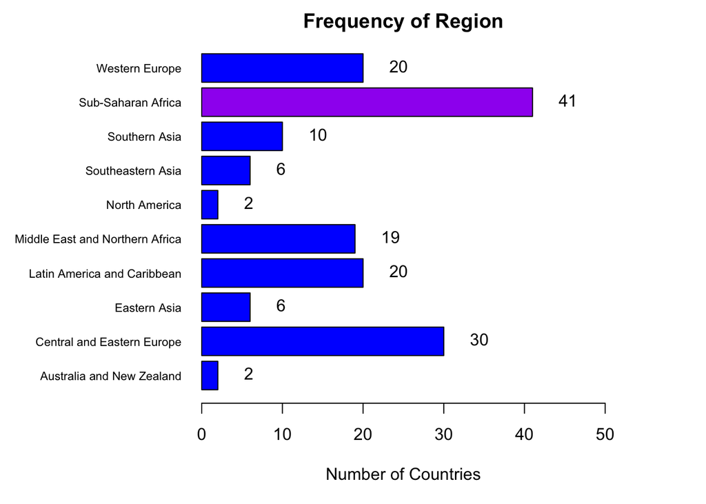

#### 2. Frequency Distribution for Europe and Asia

- i.Keep only countries that are in Europe and Asia and store them in a dataframe called `dfEA`.
- 2. Create a new variable in dfEA, `Region2`, which contains only the values “Asia” and “Europe”.
- 3. Plot the table and pie chart displaying the frequency (for table) and percentage (for pie chart) of countries in Europe and Asia. Give a title to the table and pie chart.

```r
dfEA <- HP[HP$Region %in% c("Western Europe", "Central and Eastern Europe", "Southern Asia", "Southeastern Asia","Eastern Asia"), ]
dfEA$Region2 <- ifelse(dfEA$Region %in% c("Western Europe", "Central and Eastern Europe"), "Europe", "Asia")
freq_Reg2 <- table(dfEA$Region2)
print(freq_Reg2)
```

```
##
##   Asia Europe
##     22     50
```

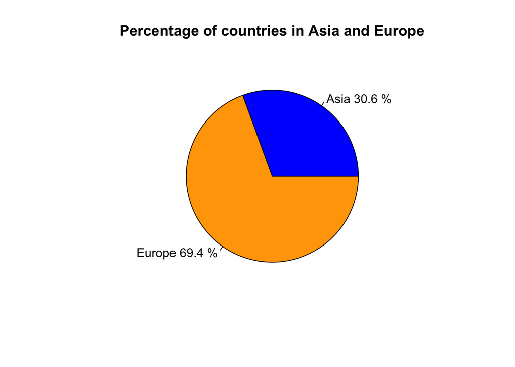

```r
pie1 <- prop.table(freq_Reg2)*100
pie(pie1,
    labels = paste(names(pie1), round(pie1, 1), "%"),
    main = "Percentage of countries in Asia and Europe",
    col = c("blue", "orange")
    )
```

#### 3. Singapore Happiness Data (2 marks)

1. extract the row of data for Singapore and display it in a table.
2. find the rank of Singapore in terms of its happiness score with Rank 1 being the happiest country

```r
singapore <- HP[HP$Country == "Singapore", ]
HP$rank <- rank(-HP$Score, ties.method = "min")
sgrank <- HP$rank[HP$Country == "Singapore"]
cat("Singapore happiness ranking", sgrank, "\n")
```

```
## Singapore happiness ranking 34
```

#### 4. Happiness Ranking

In the `HP` dataframe, create a column called `Rank` which will contain the happiness ranking for each country based on their Happiness Score where Rank will be 1 for the country with the highest score. There are no ties so the values will be from 1 to 156.

Identify which are the 5 happiest countries and 5 least happiest countries. Present your answers in two separate tables: one for the 5 happiest countries and another table for 5 least happiest countries. Each table should have three columns, namely `Country`, `Rank` and `Score`. Sort the countries in decreasing score for the 5 happiest countries and in increasing score for the 5 least happy countries. (2 marks)

```r
HP$Rank <- rank(-HP$Score, ties.method = "first")
happiest <- HP[order(-HP$Score), c("Country", "Rank", "Score")][1:5, ]
least_happy <- HP[order(HP$Score), c("Country", "Rank", "Score")][1:5, ]

print(happiest)
```

```
##         Country Rank Score
## 44      Finland    1 7.769
## 37      Denmark    2 7.600
## 106      Norway    3 7.554
## 58      Iceland    4 7.494
## 99  Netherlands    5 7.488
```

```r
print(least_happy)
```

```
##                      Country Rank Score
## 129              South Sudan  156 2.853
## 25  Central African Republic  155 3.083
## 1                Afghanistan  154 3.203
## 138                 Tanzania  153 3.231
## 118                   Rwanda  152 3.334
```

#### 5. Relationship between Life.Expectancy and Score

Plot a chart to explore the linear relationship between Score and GDP, as well as between Score and Life.Expectancy. Describe your findings. (3 marks)

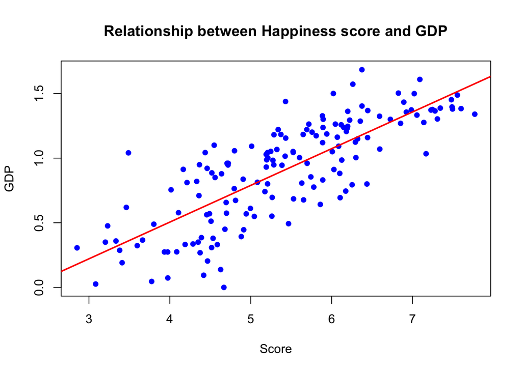

```r
plot(HP$Score,
     HP$GDP,
     main = "Relationship between Happiness score and GDP",
     xlab = "Score",
     ylab = "GDP",
     col = "blue",
     pch = 16)
abline(lm(GDP ~ Score, data = HP), col = "red", lwd = 2)
```

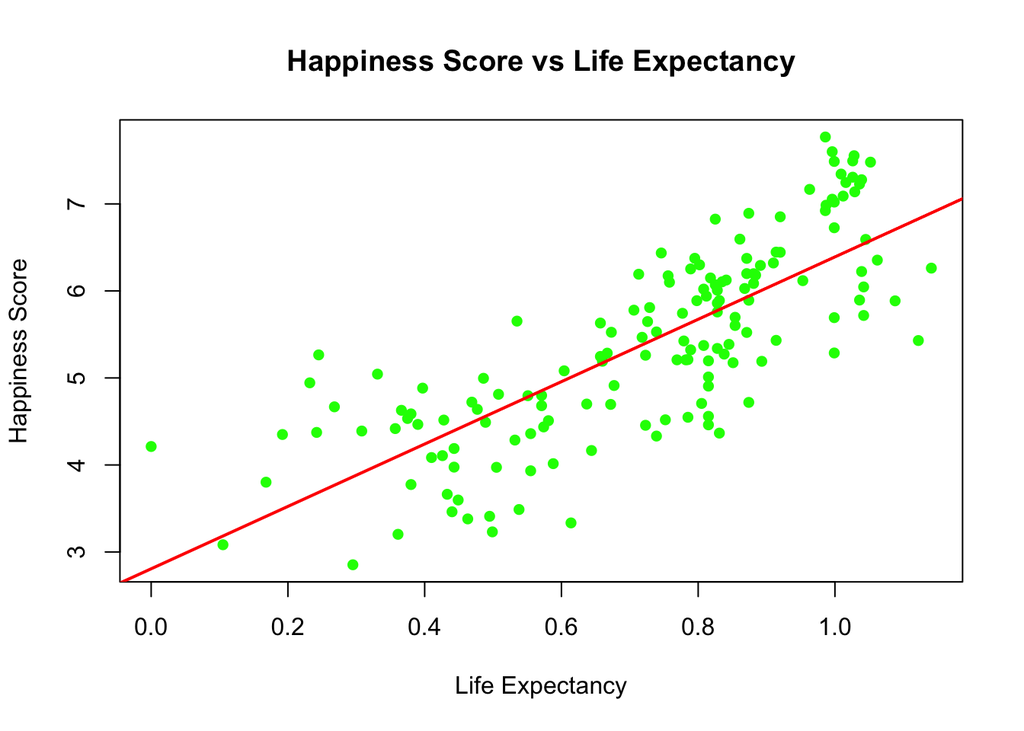

```r
plot(HP$Life.Expectancy, HP$Score,
     main = "Happiness Score vs Life Expectancy",
     xlab = "Life Expectancy",
     ylab = "Happiness Score",
     col = "green", pch = 16)
abline(lm(Score ~ Life.Expectancy, data = HP), col = "red", lwd = 2)
```

Happiness Score vs GDP - positive correlation: higher GDP per capita generally leads to higher Happiness Score. This suggests economic prosperity contributes to happiness, but the relationship may not be perfectly linear. Happiness Score vs Life Expectancy - positive correlation: higher Life Expectancy is associated with higher Happiness Score. Countries with better healthcare and living conditions tend to have higher happiness levels.

### 6. Data Checking

- 1. Check the distribution for `Score` and `Trust` by plotting a histogram, including value labels for each bar. Analize if the variables approximately normal.
- 2. Evaluate and explain if there are any outliers for these two variables Checking the data and getting it ready for further analyses.

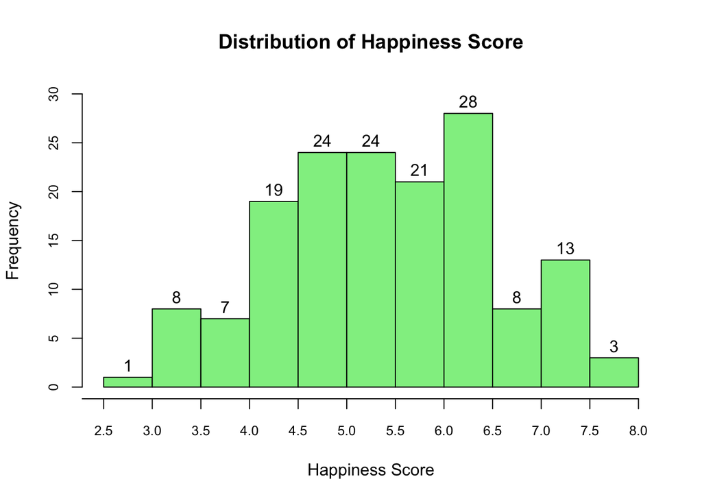

```r
#I
H2 <- hist(HP$Score,
          ylim = c(0,30),
          xaxp = c(2,8,12),
          labels = TRUE,
          main = "Distribution of Happiness Score",
          xlab = "Happiness Score",
          ylab = "Frequency",
          col = "lightgreen",
          cex.axis=0.8)
```

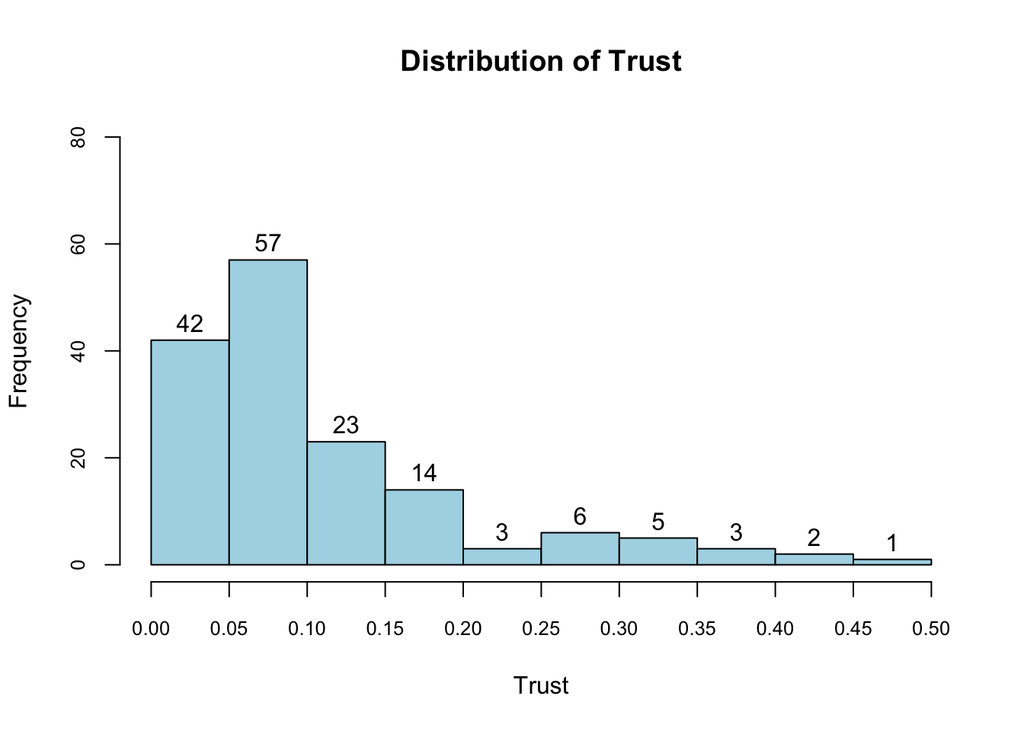

```r
H1 <- hist(HP$Trust,
          ylim = c(0,80),
          labels = TRUE,
          xaxp=c(0,0.5,10),
          main = "Distribution of Trust",
          xlab = "Trust",
          ylab = "Frequency",
          col = "lightblue",
          cex.axis=0.8)
```

```r
shapiro.test(HP$Score)
```

```
##
##  Shapiro-Wilk normality test
##
## data:  HP$Score
## W = 0.9872, p-value = 0.1633
```

```r
#W = 0.9872, p-value = 0.1633 > 0.05 => normally distributed

shapiro.test(HP$Trust)
```

```
##
##  Shapiro-Wilk normality test
##
## data:  HP$Trust
## W = 0.8228, p-value = 1.813e-12
```

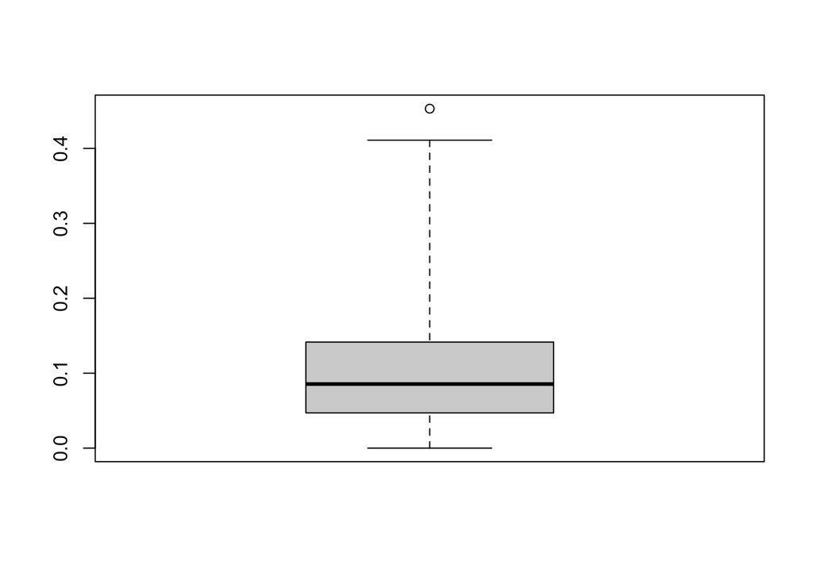

```r
#W = 0.8228, p-value = 1.813e-12 < 0.05 => not normally distributed

#II
bt3 <- boxplot(HP$Trust,
        range = 3)
```

```r
bt3$out
```

```
## [1] 0.453
```

```r
length(bt3$out)
```

```
## [1] 1
```

```r
min(bt3$out)
```

```
## [1] 0.453
```

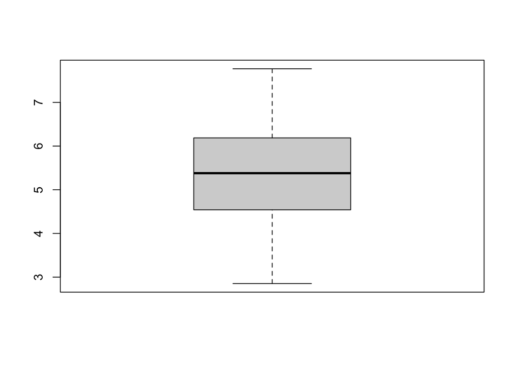

```r
#no outliners
bs3 <- boxplot(HP$Score,
        range = 3)
```

```r
#there might be outliners
```

For the boxplot One extreme outlier with value of 0.453 based on rules of thumb that is further than 3IQR from Q3 but this could also be due to the fact that the data is right skewed. No extreme outliers for score

### 7. Descriptive statistics for Happiness Score and Trust Dashboard

- 1. Generate the descriptive statistics for `Score` and `Trust` in a table, including only these statistics: mean, sd, min, max, skew, kurtosis.
- 2. Interpret the skew and kurtosis results. Is this aligned with your observation above from the histograms?

**CODE**

```r
dfScore <- HP %>%
  summarise(
    vars = "Score",
    mean = mean(Score, na.rm = TRUE),
    sd = sd(Score, na.rm = TRUE),
    min = NA,
    max = NA,
    skew = e1071::skewness(Score, na.rm = TRUE),
    kurtosis = e1071::kurtosis(Score, na.rm = TRUE)
  )

dfTrust <- HP %>%
  summarise(
    vars = "Trust",
    mean = mean(Trust, na.rm = TRUE),
    sd = sd(Trust, na.rm = TRUE),
    min = min(Trust, na.rm = TRUE),
    max = max(Trust, na.rm = TRUE),
    skew = e1071::skewness(Trust, na.rm = TRUE),
    kurtosis = e1071::kurtosis(Trust, na.rm = TRUE)
  )

dfST <- rbind(dfScore, dfTrust)
kable(dfST, row.names = FALSE, digits = 2,
      caption = "Descriptive Statistics for Score and Trust")
```

Descriptive Statistics for Score and Trust

| vars | mean | sd | min | max | skew | kurtosis |
| --- | --- | --- | --- | --- | --- | --- |
| Score | 5.41 | 1.11 | NA | NA | 0.01 | -0.66 |
| Trust | 0.11 | 0.09 | 0 | 0.45 | 1.62 | 2.23 |

Interpret Mean, sd, skew For Score: • Skewness = 0.01, which is very close to 0. • This indicates that the score variable is approximately symmetrical, confirming our observation from the histogram that it follows a bell-shaped curve. For Trust: • Skewness = 1.62, which is significantly positive. • This suggests that the trust variable has a right-skewed distribution, meaning there are more lower values with a long tail on the right. • This aligns with the histogram observation that trust is not normally distributed and is right-skewed.

### 8. Score by Region Analyses Dashboard

Let’s develop a dashboard that allows us to drill down further into the data by Region.

- 1. Generate a table that displays the number of countries, mean, standard deviation, min and max for `Score` for each region.
- 2. Add a column to the table that shows the “Coefficient of Variation” for each region and display the data in descending order of COV. Describe findings with respect to COV
- 3. Plot a chart that displays and allows easy comparison of mean Score for each Region. Describe your findings

```r
#I
tabS <- HP %>% group_by(`Region`) %>%
  summarise(n(),
            Mean_Score = round(mean(Score), 1),
            SD_Score = sd(Score),
            min = min(Score),
            max = max(Score))
kable(tabS)
```

| Region | n() | Mean_Score | SD_Score | min | max |
| --- | --- | --- | --- | --- | --- |
| Australia and New Zealand | 2 | 7.3 | 0.0558614 | 7.228 | 7.307 |
| Central and Eastern Europe | 30 | 5.6 | 0.5738283 | 4.332 | 6.852 |
| Eastern Asia | 6 | 5.7 | 0.4759401 | 5.191 | 6.446 |
| Latin America and Caribbean | 20 | 5.9 | 0.7409150 | 3.597 | 7.167 |
| Middle East and Northern Africa | 19 | 5.2 | 1.0603215 | 3.380 | 7.139 |
| North America | 2 | 7.1 | 0.2729432 | 6.892 | 7.278 |
| Southeastern Asia | 6 | 5.2 | 0.6023525 | 4.360 | 6.008 |
| Southern Asia | 10 | 4.8 | 0.8553081 | 3.203 | 6.262 |
| Sub-Saharan Africa | 41 | 4.3 | 0.6843572 | 2.853 | 6.192 |
| Western Europe | 20 | 6.9 | 0.6796091 | 5.287 | 7.769 |

```r
#II
tabS %>% mutate (COV = (SD_Score/Mean_Score)*100) %>%
arrange(desc(COV))
```

```
## # A tibble: 10 × 7
##    Region                          `n()` Mean_Score SD_Score   min   max    COV
##    <chr>                           <int>      <dbl>    <dbl> <dbl> <dbl>  <dbl>
##  1 Middle East and Northern Africa    19        5.2   1.06    3.38  7.14 20.4
##  2 Southern Asia                      10        4.8   0.855   3.20  6.26 17.8
##  3 Sub-Saharan Africa                 41        4.3   0.684   2.85  6.19 15.9
##  4 Latin America and Caribbean        20        5.9   0.741   3.60  7.17 12.6
##  5 Southeastern Asia                   6        5.2   0.602   4.36  6.01 11.6
##  6 Central and Eastern Europe         30        5.6   0.574   4.33  6.85 10.2
##  7 Western Europe                     20        6.9   0.680   5.29  7.77  9.85
##  8 Eastern Asia                        6        5.7   0.476   5.19  6.45  8.35
##  9 North America                       2        7.1   0.273   6.89  7.28  3.84
## 10 Australia and New Zealand           2        7.3   0.0559  7.23  7.31  0.765
```

Middle East & Northern show the greatest variability in happiness, meaning the happiness levels vary significantly among countries. Australia & New Zealand have the lowest COV, indicating that happiness levels are quite consistent across countries in these regions.

Since we are comparing countries in different regions, their data may be on different scales. • Variance alone is misleading when comparing datasets with different means. • CV standardizes variability, making it a better metric for comparing variation across different regions.

[figure not shown]

```r
#III
par(mar=c(5,7,4,2))
bar <- as.matrix(tabS$Mean_Score)
barplot(bar,
        names.arg = tabS$Region,
        beside=TRUE,
        col= "skyblue",
        main = "Mean Happiness Score by Regions",
        cex.names= 0.8,
        las = 2,
        ylab = "Score",
        ylim = c(0,9)
        )
text(x = 1.5:length(tabS$Region),
     y = tabS$Mean_Score,
     labels= round(tabS$Mean_Score,1),
     pos = 3,
     cex = 0.8,
     col = "black")
```

### 9. Correlation Analyses

Let’s explore the linear relationship between `Score` and the other 6 factors.

- 1. Create a correlation matrix for the 7 variables of interest using corr.test
- 2. Describe the strength, direction and significance of the linear relationship between Happiness Score and the other 6 variables.

```r
library(psych)
#I
correlation_matrix <- corr.test(HP[3:9])
print(correlation_matrix$r, digits = 2)
```

```
##                 Score   GDP Family Life.Expectancy Freedom Trust Generosity
## Score           1.000  0.79  0.777            0.78    0.57  0.39      0.076
## GDP             0.794  1.00  0.755            0.84    0.38  0.30     -0.080
## Family          0.777  0.75  1.000            0.72    0.45  0.18     -0.048
## Life.Expectancy 0.780  0.84  0.719            1.00    0.39  0.30     -0.030
## Freedom         0.567  0.38  0.447            0.39    1.00  0.44      0.270
## Trust           0.386  0.30  0.182            0.30    0.44  1.00      0.327
## Generosity      0.076 -0.08 -0.048           -0.03    0.27  0.33      1.000
```

```r
#p value
print(correlation_matrix$p, digits = 2)
```

```
##                   Score     GDP  Family Life.Expectancy Freedom   Trust
## Score           0.0e+00 8.6e-34 1.6e-31         7.2e-32 1.9e-13 7.3e-06
## GDP             4.3e-35 0.0e+00 8.8e-29         1.5e-40 1.1e-05 1.2e-03
## Family          9.0e-33 5.2e-30 0.0e+00         6.6e-25 6.7e-08 1.2e-01
## Life.Expectancy 3.8e-33 7.0e-42 4.1e-26         0.0e+00 5.6e-06 1.3e-03
## Freedom         1.2e-14 1.1e-06 4.8e-09         4.7e-07 0.0e+00 1.3e-07
## Trust           6.7e-07 1.5e-04 2.3e-02         1.8e-04 1.0e-08 0.0e+00
## Generosity      3.5e-01 3.2e-01 5.5e-01         7.1e-01 6.6e-04 3.2e-05
##                 Generosity
## Score              1.00000
## GDP                1.00000
## Family             1.00000
## Life.Expectancy    1.00000
## Freedom            0.00397
## Trust              0.00029
## Generosity         0.00000
```

```r
#II
# if r > 0 (eg r= 0.850) => Strength: Strong positive relationship, Positive direction (as Factor1 increases, HappinessScore tends to increase). p <0.05 (eg: p= 0.001, so the relationship is statistically significant.

#SIGNIFICANCE
#Score vs. GDP: p-value: 8.6e-34 (≈ 0.000) => Significance: Statistically significant.
#Score vs. Family: p-value: 1.6e-31 (≈ 0.000) => Significance: Statistically significant.
#Score vs. Life.Expectancy: p-value: 7.2e-32 (≈ 0.000) => Significance: Statistically significant.
#Score vs. Freedom: p-value: 1.9e-13 (≈ 0.000) => Significance: Statistically significant.
#Score vs. Trust: p-value: 7.3e-06 (≈ 0.000) => Significance: Statistically significant.
#Score vs. Generosity: p-value: 1.00000 => Significance: Not statistically significant.

#STRENGTH & DIRECTION
#Score vs. GDP: Correlation (r): 0.794 => Strength: Strong positive relationship.Direction: Positive (as GDP increases, Score tends to increase).
#Score vs. Family: (r): 0.777 => Strong positive relationship. Positive Direction (as Family increases, Score tends to increase).
#Score vs. Life.Expectancy: (r): 0.780 => Strong positive relationship. Positive Direction (as Life.Expectancy increases, Score tends to increase).
#Score vs. Freedom: (r): 0.567 => Moderate positive relationship. Positive Direction (as Freedom increases, Score tends to increase).
#Score vs. Trust (r): 0.386 => Weak positive relationship.Positive Direction (as Trust increases, Score tends to increase slightly).
#Score vs. Generosity (r): 0.076 => Very weak or negligible relationship.Positive Direction (as Generosity increases, Score tends to increase very slightly).
```

If r > 0 (eg r= 0.850) => Strength: Strong positive relationship, Positive direction (as Factor1 increases, HappinessScore tends to increase). p <0.05 (eg: p= 0.001, so the relationship is statistically significant.

We observe a strong positive correlation between Happiness Score and GDP. With a p-value smaller than 0.05, this correlation is statistically significant (significantly different from 0) GDP • Correlation: 0.79 (strong positive correlation) • Significance: p = 0.00 (highly significant) Freedom Correlation: 0.57 (moderate positive correlation) • Significance: p = 0.00 (highly significant) Generosity • Correlation: 0.08 (weak positive correlation) • Significance: p = 0.35 (not significant) …

STRENGTH & DIRECTION - Score vs. GDP: Correlation (r): 0.794 => Strength: Strong positive relationship.Direction: Positive (as GDP increases, Score tends to increase). - Score vs. Family: (r): 0.777 => Strong positive relationship. Positive Direction (as Family increases, Score tends to increase).

### 10.Computing Proportions and Probabilities for Sub-Saharan Africa region

- 1. What proportion of countries have a happiness score that is lower than the average score in the region?
- 2. Assuming the Score data is normally distributed, what is the probability of a country having a Score more than 5?

```r
#i
dfa <- HP[HP$Region == "Sub-Saharan Africa", ]
avgscore <- mean(dfa$Score)
P1 <- dfa %>% filter(Score<avgscore)
proportion <- nrow(P1)/nrow(dfa)
#ANSWER: the proportion of countries have a happiness score that is lower than the average score in the region is 41,46%
#ii
sd_score <- sd(dfa$Score)
z_score <- (5 - avgscore) / sd_score
probability <- 1 - pnorm(z_score)
probability
```

```
## [1] 0.1696988
```

```r
#ANSWER: the probability of a country having a Score more than 5 is 16,97%
```

Can use : pnorm(5,mean=mScore, sd(HPssa$Score),lower.tail = F) - pnorm(quantile, mean, sd) : Find probability from quantile - qnorm(probability, mean, sd):Find quantile from probability

[output not shown]

```
##       Country                          Region Rank Score.2019   GDP Family
## 1 Afghanistan                   Southern Asia  154      3.203 0.350  0.517
## 2     Albania      Central and Eastern Europe  107      4.719 0.947  0.848
## 3     Algeria Middle East and Northern Africa   88      5.211 1.002  1.160
## 4   Argentina     Latin America and Caribbean   47      6.086 1.092  1.432
## 5     Armenia      Central and Eastern Europe  116      4.559 0.850  1.055
## 6   Australia       Australia and New Zealand   11      7.228 1.372  1.548
##   Life.Expectancy Freedom Trust Generosity Score.2018
## 1           0.361   0.000 0.025      0.158      3.632
## 2           0.874   0.383 0.027      0.178      4.586
## 3           0.785   0.086 0.114      0.073      5.295
## 4           0.881   0.471 0.050      0.066      3.795
## 5           0.815   0.283 0.064      0.095      6.388
## 6           1.036   0.557 0.290      0.332      4.321
```

### 11.Comparing Average Score in 2019 across Regions

1. Create a new categorical variable `Region2` to contain 4 possible values (Africa, American, Asia, Europe). `Region2` should be assigned the value of “Asia” if `Region` is “Australia and New Zealand” or contains “Asia”. `Region2` should be assigned the value of “Europe” if `Region` contains “Europe”. `Region2` should be assigned the value of “America” if `Region` contains “America” and `Region2` should be assigned the value of “Africa” if `Region` contains “Africa”.
2. Display the mean, standard deviation, min and max of score in 2019 for each of the 4 regions (defined by `Region2`) in a table. Describe any interesting patterns/observations you can make from the table.
3. Now, conduct the appropriate test(s) to assess if there is any difference in mean 2019 score across regions (as defined by `Region2`. State your hypotheses clearly, ensuring all symbols and groups are defined. Describe your conclusion with reference to the results. You may assume score to be normally distributed.

**CODE**

```r
#i
dregion <- d2 %>% mutate(Region2 = case_when(
  Region == "Australia and New Zealand" ~ "Asia",
  grepl("Asia", Region) ~ "Asia",
  grepl("Europe", Region) ~ "Europe",
  grepl("America", Region) ~ "America",
  grepl("Africa", Region) ~ "Africa",
))

#ii
tabs <- dregion %>% group_by(`Region2`) %>%
  summarise(n(),
            Mean_Score = round(mean(Score.2019), 1),
            SD_Score = sd(Score.2019),
            min = min(Score.2019),
            max = max(Score.2019))
kable(tabs)
```

| Region2 | n() | Mean_Score | SD_Score | min | max |
| --- | --- | --- | --- | --- | --- |
| Africa | 60 | 4.6 | 0.9138628 | 2.853 | 7.139 |
| America | 22 | 6.0 | 0.7830867 | 3.597 | 7.278 |
| Asia | 24 | 5.3 | 0.9506733 | 3.203 | 7.307 |
| Europe | 50 | 6.1 | 0.8990315 | 4.332 | 7.769 |

```r
#iii

anova_result <- aov(Score.2019 ~ Region2, data = dregion)
anova_summary <- summary(anova_result)
anova_summary
```

```
##              Df Sum Sq Mean Sq F value  Pr(>F)
## Region2       3  69.51  23.169   28.74 8.9e-15 ***
## Residuals   152 122.54   0.806
## ---
## Signif. codes:  0 '***' 0.001 '**' 0.01 '*' 0.05 '.' 0.1 ' ' 1
```